# EpiTox: Full annotations

Hoor Al-Hasani

2026-03-23

# Declare libraries

### Reading input

the input to the model is all the annotations that EpiTox extracted from IEDB. For this target (*MAGEA4*), both HLA-ligand atlas and PEPREP contribution was subset of the IEDB whole annotation. See notes bellow to understand some of the decisions that were made.

The input is:

- the final table from V2.5’s `annotopes`: *HPA_genes_nTPM.xlsx*
- the experimental evidence file from the previous step
- *IEDB* annotated peptides

## Step 1: Estimate *Experimental Evidence*

The experimental evidence is a Baysian-based model to evaluate and summarize the context evidence that is available for each peptide. the concept is to determine the peptide with its protein ensuring context aware evaluation.

```
[1] "24 files were found!"
```

```
 [1] "chr_1_IEDB_annotation_sequence.csv"  "chr_10_IEDB_annotation_sequence.csv"
 [3] "chr_11_IEDB_annotation_sequence.csv" "chr_12_IEDB_annotation_sequence.csv"
 [5] "chr_13_IEDB_annotation_sequence.csv" "chr_14_IEDB_annotation_sequence.csv"
 [7] "chr_15_IEDB_annotation_sequence.csv" "chr_16_IEDB_annotation_sequence.csv"
 [9] "chr_17_IEDB_annotation_sequence.csv" "chr_18_IEDB_annotation_sequence.csv"
[11] "chr_19_IEDB_annotation_sequence.csv" "chr_2_IEDB_annotation_sequence.csv"
[13] "chr_20_IEDB_annotation_sequence.csv" "chr_21_IEDB_annotation_sequence.csv"
[15] "chr_22_IEDB_annotation_sequence.csv" "chr_3_IEDB_annotation_sequence.csv"
[17] "chr_4_IEDB_annotation_sequence.csv"  "chr_5_IEDB_annotation_sequence.csv"
[19] "chr_6_IEDB_annotation_sequence.csv"  "chr_7_IEDB_annotation_sequence.csv"
[21] "chr_8_IEDB_annotation_sequence.csv"  "chr_9_IEDB_annotation_sequence.csv"
[23] "chr_X_IEDB_annotation_sequence.csv"  "chr_Y_IEDB_annotation_sequence.csv"
```

### Core analysis

process experimental data, followed by bayesian assessment then saving the results

#### Generate plots

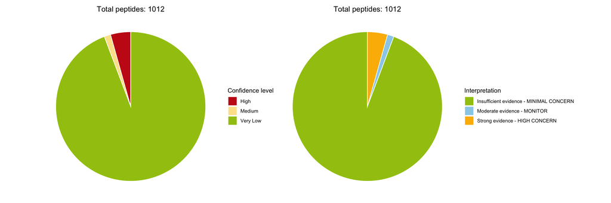

```
  confidence_level count
1             High    44
2           Medium    14
3         Very Low   954
```

## Step 2: TPT

### Target

```
=== POSITION CLASSIFICATION ===

Position categories (counts):

Classical Anchor          Neutral       Permissive
               2                5                3


Classical Anchors (high sensitivity, intolerant to mutations):
  Position      WT_AA Fold_Change_Mean Percent_Better_Than_WT
1        2 GVYDGREHTV          65.8436               15.78947
2       10 GVYDGREHTV         159.1055                0.00000


Permissive Positions (tolerate many substitutions):
  Position      WT_AA Fold_Change_Mean Percent_Better_Than_WT
1        1 GVYDGREHTV        6.9234111               52.63158
2        6 GVYDGREHTV        0.6599772              100.00000
3        7 GVYDGREHTV        0.7958463               89.47368


Flexible Anchors (high sensitivity BUT also allow good alternatives):
[1] Position               WT_AA                  Fold_Change_Mean
[4] Percent_Better_Than_WT Best_Improvement
<0 rows> (or 0-length row.names)
```

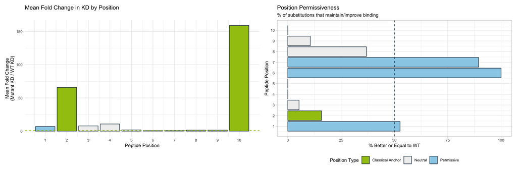

### Off-target classification

```
  uniprot    peptide Overall_Identity Total_Mismatches Anchor_Mismatches
1  P43358 GVYDGREHTV              100                0                 0
2  P43358 GLYDGREHTV               90                1                 1
3  P43361 GLYDGREHSV               80                2                 1
4  Q9UBF1 GVYAGREHFV               80                2                 0
5  O15479 GVYDGEEHSV               80                2                 0
6  P43355 EVYDGREHSA               70                3                 1
  Anchor_Percent_Diff Exposed_Mismatches Exposed_Percent_Diff Both_Mismatches
1                   0                  0                  0.0               0
2                  50                  0                  0.0               0
3                  50                  1                 12.5               0
4                   0                  2                 25.0               0
5                   0                  2                 25.0               0
6                  50                  2                 25.0               0
  Both_Percent_Diff               Category
1                 0          Perfect Match
2                 0            Anchor Only
3                 0 Both Anchor & Backbone
4                 0          Backbone Only
5                 0          Backbone Only
6                 0 Both Anchor & Backbone
```

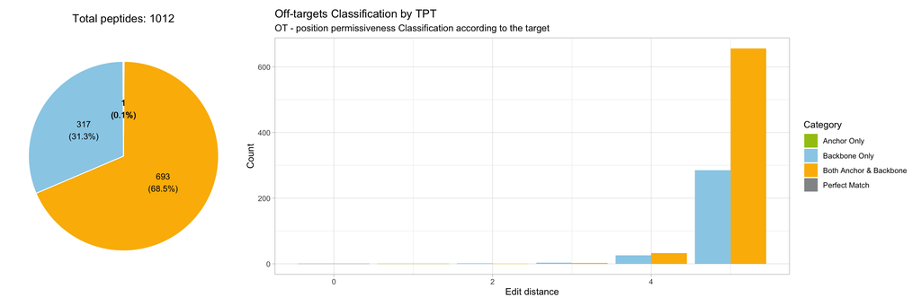

## Step 3: Estimate *Multi-Features score*

```r
print(anchor_positions)
```

```
## [1]  2 10
```

```r
print(BACKBONE_POSITIONS)
```

```
## [1] 3 4 5 6 7 8 9
```

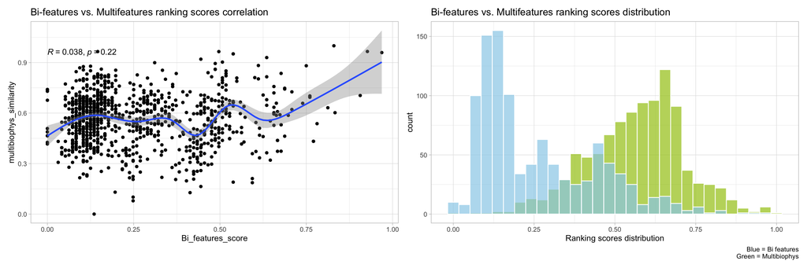

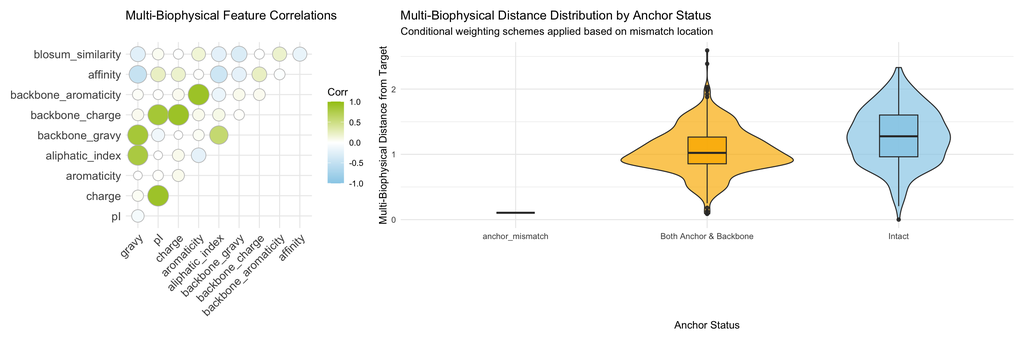

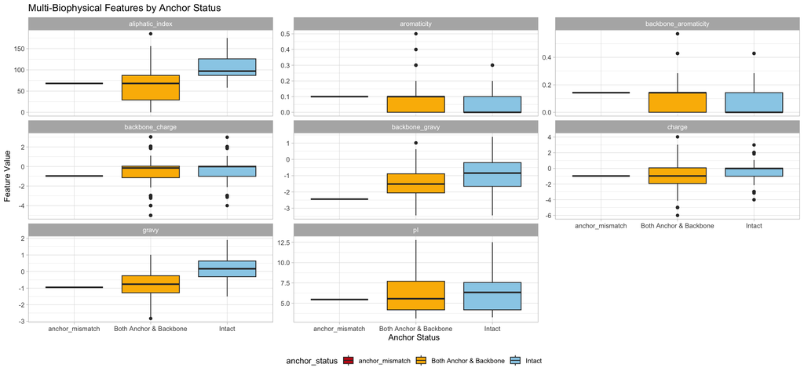

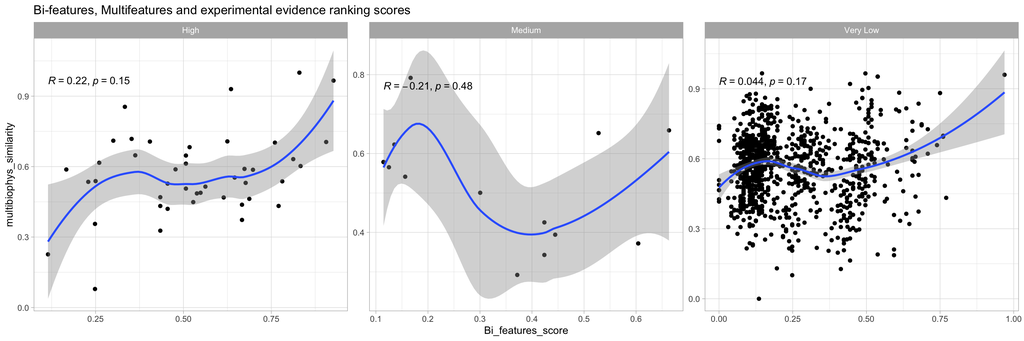

# Get HighScore resutls

| VR | TPP | anabel |
| --- | --- | --- |
| 4 | 104 | NA |
| 6 | 106 | 104 |
| 57 | 96 | 104 |
| 58 | 98 | 104 |

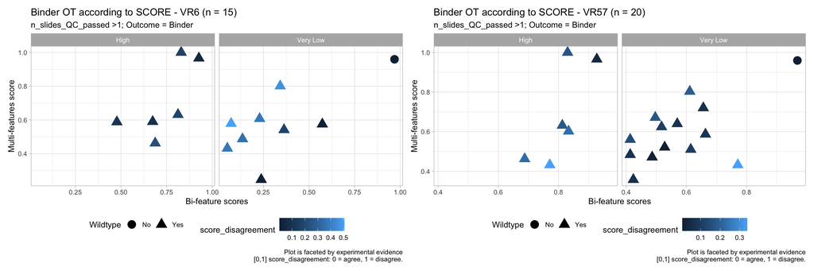

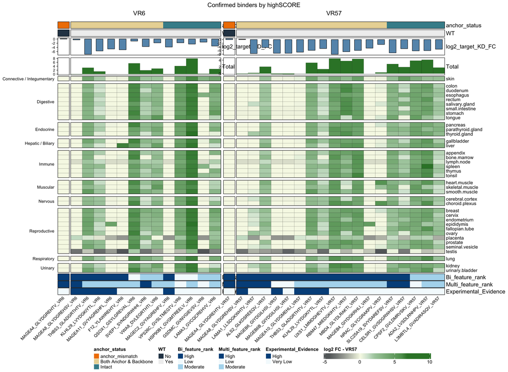

| antibody | uniprot | peptide | Wildtype | mismatch | anchor_status | blosum_similarity | affinity | Bi_features_score | multibiophys_similarity | confidence_level | KD | log2_target_FC | Outcome |
| --- | --- | --- | --- | --- | --- | --- | --- | --- | --- | --- | --- | --- | --- |
| VR57 | P43358 | GVYDGREHTV | Yes | 0 | Intact | 56 | 51.1040374973909 | 0.83 | 1 | High | 1.899577126001905e-08 | -0.080281750710925 | Binder |
| VR57 | P43358 | GLYDGREHTV | No | 1 | anchor_mismatch | 53 | 27.5382564296698 | 0.96875 | 0.9595511941416364 | Very Low | 1.285631694335823e-08 | 0.5632008880780333 | Binder |
| VR57 | P43361 | GLYDGREHSV | Yes | 2 | Both Anchor &amp; Backbone | 49 | 30.175926433102 | 0.927083333333333 | 0.9661419509215295 | High | 1.624583494998121e-08 | 0.2256083965522204 | Binder |
| VR57 | P49746 | GLADGRTHTV | Yes | 3 | Both Anchor &amp; Backbone | 38 | 40.0202579929705 | 0.8125 | 0.6318271024730484 | High | 1.146789003980563e-06 | -5.915777877190341 | Binder |
| VR57 | Q9NYQ6 | GVSDGRWHSV | Yes | 3 | Intact | 35 | 312.262857575442 | 0.61125 | 0.8032876386867089 | Very Low | 6.051773613280424e-07 | -4.993607825626398 | Binder |
| VR57 | P43363 | GLYDGMEHLI | Yes | 4 | Both Anchor &amp; Backbone | 40 | 35.4111816040768 | 0.833333333333333 | 0.6023985835932371 | High | 2.269292131426408e-06 | -6.900420243319066 | Binder |
| VR57 | Q9HC21 | SVYDAREFSV | Yes | 4 | Intact | 31 | 57.4957977367604 | 0.569583333333333 | 0.6398574119272965 | Very Low | 2.960425492809061e-06 | -7.283982445613425 | Binder |
| VR57 | A0A0J9YX57 | GIYDGILHSI | Yes | 5 | Both Anchor &amp; Backbone | 34 | 25.7992903268336 | 0.770833333333333 | 0.4324177825690987 | Very Low | 3.479527969766368e-06 | -7.517069505144091 | Binder |
| VR57 | Q8N7X4 | GIYDGILHSI | Yes | 5 | Both Anchor &amp; Backbone | 34 | 25.7992903268336 | 0.770833333333333 | 0.4324177825690987 | High | 3.479527969766368e-06 | -7.517069505144091 | Binder |
| VR57 | O15481 | GIYDGKRHLI | Yes | 5 | Both Anchor &amp; Backbone | 40 | 139.541209019186 | 0.663333333333333 | 0.5869347891427708 | Very Low | 4.905147293587884e-07 | -4.690546264746999 | Binder |

[output cut: 25 more lines]

# Notes

## Experimental evidence

In the experimental evidence scoring, HLA-ligand Atlas and PEPREP were not used due to the following reasons:

- *PEPREP*: At the time, data extraction was not possible from peprep and the schema was not stabilitzed enough to track down the information correctly
- *HLA-ligand atlas*: at the time there was no real solution for the incomplete mapping between allele-tissue-peptide problem